# Exploratory Data Analysis - Work in Progress

Nikita Jain and Kelsang Tsomo

# Purpose

This file contains exploratory visualizations and code experiments conducted during the analysis process. Not all visualizations here made it into the final report. This demonstrates our iterative approach to finding the most effective way to communicate our findings about the relationship between women’s empowerment and fertility decline in high-income nations.

```r
# import libraries
library(dplyr)
library(readxl)
library(tidyr)
library(countrycode)
library(ggplot2)
library(scales)
library(ggrepel)
library(plotly)
```

# Data Loading and Preparation

```r
# loading world bank data, getting the high income countries
wb_file_path <- "WorldBankData.csv"

wb_data_raw <- read.csv(
  wb_file_path,
  stringsAsFactors = FALSE,
  check.names = FALSE
)

year_cols <- grep("\\[YR\\d{4}\\]", names(wb_data_raw), value = TRUE)
years <- as.numeric(gsub(".*\\[YR(\\d{4})\\]", "\\1", year_cols))

wb_data_long <- wb_data_raw %>%
  select(`Country Name`, `Country Code`, `Series Name`, `Series Code`, all_of(year_cols)) %>%
  pivot_longer(
    cols = all_of(year_cols),
    names_to = "year_col",
    values_to = "value"
  ) %>%
  mutate(
    year = as.numeric(gsub(".*\\[YR(\\d{4})\\]", "\\1", year_col)),
    value = as.numeric(value)
  ) %>%
  select(-year_col) %>%
  filter(!is.na(value))

wb_data <- wb_data_long %>%
  select(-`Series Name`) %>%
  pivot_wider(
    names_from = `Series Code`,
    values_from = value,
    id_cols = c(`Country Name`, `Country Code`, year)
  ) %>%
  rename (
    country = `Country Name`,
    iso3c = `Country Code`,
    gni_per_capita = NY.GNP.PCAP.CD,
    fertility_rate = SP.DYN.TFRT.IN,
    population_growth = SP.POP.GROW,
    old_age_dependency = SP.POP.DPND.OL,
    female_lfpr = SL.TLF.CACT.FE.ZS
  )

cat("World Bank data loaded successfully!\n")
```

```
## World Bank data loaded successfully!
```

```r
gni_threshold <- 13205

high_income_countries <- wb_data %>%
  filter(year == max(year), !is.na(gni_per_capita)) %>%
  filter(gni_per_capita >= gni_threshold) %>%
  filter(!country %in% c("High income", "Low income", "Middle income",
                      "Upper middle income", "Lower middle income",
                      "OECD members", "World", "European Union",
                      "East Asia & Pacific", "Europe & Central Asia",
                      "Latin America & Caribbean", "Middle East & North Africa",
                      "North America", "South Asia", "Sub-Saharan Africa")) %>%
  select(country, iso3c, gni_per_capita) %>%
  distinct()
```

```r
# loading UNICEF data
unicef_file_path <- "SOWC_tables.xlsx"

demographics <- read_excel(
  path = unicef_file_path,
  sheet = 1,
  skip = 7,
  n_max = 217,
  col_names = c(
    "country",
    "population_2023_thousands_total", NA,
    "population_2023_thousands_under18", NA,
    "population_2023_thousands_under5", NA,
    "annual_population_growth_rate_perc", NA,
    "annual_population_growth_rate_perc_A", NA,
    "annual_number_of_births_thousands_2023", NA,
    "total_live_births_per_woman_2023", NA,
    "life_expectancy_at_birth_1970", NA,
    "life_expectancy_at_birth_2000", NA,
    "life_expectancy_at_birth_2023", NA,
    "dependency_ratio_total", NA,
    "dependency_ratio_child", NA,
    "dependency_ratio_old_age", NA,
    "share_of_urban_population_perc_2023", NA,
    "annual_growth_rate_of_urban_population_perc_2000-2020", NA,
    "annual_growth_rate_of_urban_population_perc_2000-2020_A", NA,
    "net_migration_rate_per_thousand_2023"
  )
) |>
  select(-starts_with("...")) |>
  filter(!is.na(country), country != "SUMMARY") |>
  mutate(across(-country, as.numeric))

women_empowered <- read_excel(
  path = unicef_file_path,
  sheet = 17,
  skip = 7,
  n_max = 217,
  col_names = c(
    "country",
    "SIGI_2023",
    "legal_gender_equality_in_employment_201802022",
    "maternity_leave_benefits_2024",
    "paternity_leave_benefits_2024",
    "attained_upper_secondary_education_perc_2014-2023_male", NA,
    "attained_upper_secondary_education_perc_2014-2023_female", NA,
    "labour_force_participation_rate_2019-2023_rural_male", NA,
    "labour_force_participation_rate_2019-2023_urban_male", NA,
    "labour_force_participation_rate_2019-2023_male", NA,
    "labour_force_participation_rate_2019-2023_rural_female", NA,
    "labour_force_participation_rate_2019-2023_urban_female", NA,
    "labour_force_participation_rate_2019-2023_female", NA,
    "unemployment_rate_2019-2023_rural_male", NA,
    "unemployment_rate_2019-2023_urban_male", NA,
    "unemployment_rate_2019-2023_male", NA,
    "unemployment_rate_2019-2023_rural_female", NA,
    "unemployment_rate_2019-2023_urban_female", NA,
    "unemployment_rate_2019-2023_female", NA,
    "mobile_phone_ownership_perc_2014-2023_male", NA,
    "mobile_phone_ownership_perc_2014-2023_female", NA,
    "financial_inclusion_perc_2014-2022_male",
    "financial_inclusion_perc_2014-2022_female",
    "time_use_perc_2014-2023_male",
    "time_use_perc_2014-2023_female"
  )
) |>
  select(-starts_with("...")) |>
  filter(!is.na(country), country != "SUMMARY") |>
  mutate(
    across(
      -c(country, maternity_leave_benefits_2024, paternity_leave_benefits_2024),
      as.numeric
    )
  )

social_protection <- read_excel(
  path = unicef_file_path,
  sheet = 13,
  skip = 7,
  n_max = 217,
  col_names = c(
    "country",
    "new_mothers_cash_benefit_perc_2015-2023",
    "children_covered_by_social_protection_perc_2015-2023", NA,
    "social_protection_benefits_perc_2015-2021_bottom40",
    "social_protection_benefits_perc_2015-2021_top20",
    "social_protection_benefits_perc_2015-2021_bottom20",
    "share_of_household_income_2015-2023_bottom40",
    "share_of_household_income_2015-2023_top20",
    "share_of_household_income_2015-2023_bottom20",
    "gini_coefficient_2015-2023",
    "palma_index_2015-2023",
    "VMIR_2010-2019",
    "GDP_per_capita_2015-2023",
    "children_material_deprivation_2011-2019_1D", NA,
    "children_material_deprivation_2011-2019_2D", NA,
    "children_material_deprivation_2011-2019_3D", NA,
    "children_material_deprivation_2011-2019_more"
  )
) |>
  select(-starts_with("...")) |>
  filter(!is.na(country), country != "SUMMARY") |>
  mutate(across(-country, as.numeric))

unicef_combined <- demographics %>%
  select(country,
         total_live_births_per_woman_2023,
         dependency_ratio_old_age,
         life_expectancy_at_birth_2023) %>%
  left_join (
    women_empowered %>%
      select(country,
             SIGI_2023,
             maternity_leave_benefits_2024,
             paternity_leave_benefits_2024,
            `attained_upper_secondary_education_perc_2014-2023_female`,
            `labour_force_participation_rate_2019-2023_female`,
            `financial_inclusion_perc_2014-2022_female`,
            `time_use_perc_2014-2023_female`),
    by = "country"
  ) %>%
  left_join(
    social_protection %>%
      select(country,
            `new_mothers_cash_benefit_perc_2015-2023`),
    by = "country"
  )

unicef_combined <- unicef_combined %>%
  mutate(
    iso3c = countrycode(
      country,
      origin = "country.name",
      destination = "iso3c",
      warn = FALSE
    )
  )

unicef_high_income <- unicef_combined %>%
  inner_join(
    high_income_countries %>% select(iso3c),
    by = "iso3c"
  )

wb_high_income <- wb_data %>%
  inner_join(
    high_income_countries %>% select(iso3c),
    by = "iso3c"
  ) %>%
  filter(year >= 2015 & year <= 2023)

years_available <- sort(unique(wb_high_income$year))

unicef_panel <- expand.grid(
  iso3c = unique(unicef_high_income$iso3c),
  year = years_available,
  stringsAsFactors = FALSE
) %>%
  left_join(
    unicef_high_income,
    by = "iso3c"
  )

final_dataset <- wb_high_income %>%
  inner_join(
    unicef_panel,
    by = c("iso3c", "year"),
    suffix = c("_wb", "_unicef")
  ) %>%
  mutate(country = dplyr::coalesce(country_unicef, country_wb)) %>%
  select(-country_wb, -country_unicef) %>%
  mutate(
    has_maternity_leave = !is.na(maternity_leave_benefits_2024) &
      !grepl("No|None|^-$", maternity_leave_benefits_2024, ignore.case = TRUE),
    has_paternity_leave = !is.na(paternity_leave_benefits_2024) &
      !grepl("No|None|^-$", paternity_leave_benefits_2024, ignore.case = TRUE),
    education_female = `attained_upper_secondary_education_perc_2014-2023_female`,
    labour_part_female = `labour_force_participation_rate_2019-2023_female`,
    financial_inclusion_female = `financial_inclusion_perc_2014-2022_female`,
    unpaid_work_share_female = `time_use_perc_2014-2023_female`
  ) %>%
  select(-total_live_births_per_woman_2023, -dependency_ratio_old_age) %>%
  arrange(country, year) %>%
  select(country, year, everything())

final_dataset_30 <- final_dataset %>%
  filter(year == 2023, !is.na(gni_per_capita)) %>%
  filter(!country %in% c("Turks and Caicos Islands", "Andorra")) %>%
  arrange(desc(gni_per_capita)) %>%
  slice(1:30) %>%
  select(country) %>%
  left_join(final_dataset, by = "country") %>%
  mutate(
    country = case_when(
      country == "Republic of Korea" ~ "South Korea",
      country == "United States" ~ "U.S.",
      country == "United Arab Emirates" ~ "UAE",
      country == "Hong Kong SAR, China" ~ "Hong Kong",
      country == "Macao SAR, China" ~ "Macao",
      country == "Slovak Republic" ~ "Slovakia",
      TRUE ~ country
    )
  )

top_30_richest <- unique(final_dataset_30$country)
cat("Top 30 countries loaded\n")
```

```
## Top 30 countries loaded
```

# Visualization Experiments

## Attempt 1: Faceted Country-by-Country Analysis (Kelsang)

**Why we tried this:** Wanted to see individual country patterns in detail and show the correlation between fertility decline and aging.

**Why it didn’t work:** Too overwhelming with 30 small panels. Hard to compare across countries or identify overall patterns. Readers would need to examine each panel individually rather than seeing the big picture.

**Decision:** Moved toward aggregated visualizations and scatterplots instead.

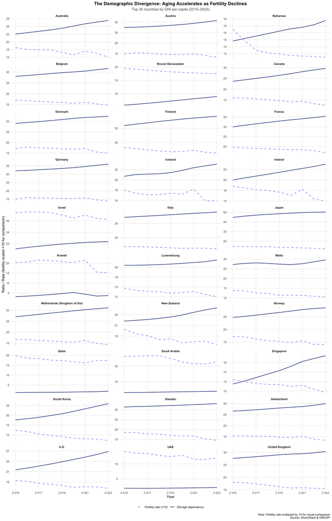

```r
top30 <- final_dataset_30 |>
  filter(!is.na(gni_per_capita)) |>
  group_by(country) |>
  summarise(gni_last = last(gni_per_capita[order(year)]), .groups = "drop") |>
  arrange(desc(gni_last)) |>
  slice_head(n = 30)

plot_df <- final_dataset_30 |>
  inner_join(top30, by = "country") |>
  filter(!is.na(old_age_dependency), !is.na(fertility_rate), !is.na(year)) %>%
  mutate(
    income_category = case_when(
      gni_per_capita >= 70000 ~ "Highest Income",
      gni_per_capita >= 50000 ~ "High Income",
      gni_per_capita >= 30000 ~ "Upper-Middle Income",
      TRUE ~ "Middle Income"
    ),
    income_category = factor(
      income_category,
      levels = c("Highest Income", "High Income",
                 "Upper-Middle Income", "Middle Income")
    )
  )

p <- ggplot(plot_df, aes(x = year)) +
  geom_line(aes(y = old_age_dependency, color = "Old-age dependency"),
            linewidth = 0.8, alpha = 0.9) +
  geom_line(aes(y = fertility_rate * 10, color = "Fertility rate (×10)"),
            linewidth = 0.8, linetype = "dashed", alpha = 0.9) +
  facet_wrap(~ country, ncol = 3, scales = "free_y") +
  scale_color_manual(
    values = c("Old-age dependency" = "#1e3a8a",
               "Fertility rate (×10)" = "#a78bfa"),
    name = NULL
  ) +
  scale_x_continuous(
    breaks = seq(2015, 2023, 2),
    labels = number_format(accuracy = 1)
  ) +
  scale_y_continuous(
    labels = number_format(accuracy = 1)
  ) +
  labs(
    title = "The Demographic Divergence: Aging Accelerates as Fertility Declines",
    subtitle = "Top 30 countries by GNI per capita (2015–2023)",
    x = "Year",
    y = "Ratio / Rate (fertility scaled ×10 for comparison)",
    caption = "Note: Fertility rate multiplied by 10 for visual comparison\nSource: World Bank & UNICEF"
  ) +
  theme_minimal(base_size = 11) +
  theme(
    legend.position = "bottom",
    strip.text = element_text(face = "bold", size = 9),
    panel.grid.minor = element_blank(),
    plot.title = element_text(face = "bold", size = 14, hjust = 0.5),
    plot.subtitle = element_text(size = 11, color = "gray30", hjust = 0.5)
  )

print(p)
```

## Attempt 2: Pattern-Based Categorization (Kelsang)

**Approach:** Group countries into subjective categories like “Rapid Aging,” “Sharp Decline,” and “Stable Fertility” based on their demographic profiles.

**Why we tried this:** Wanted to highlight countries with similar trajectories and tell stories about different demographic patterns.

**Why it didn’t work:** Categories felt arbitrary and subjective. Hard to justify why Japan is “Rapid Aging” but Singapore is “Sharp Decline” when both have severe problems. Didn’t align with our main argument about income-driven patterns.

**Decision:** Switched to objective World Bank income classifications instead, which are standardized and widely recognized.

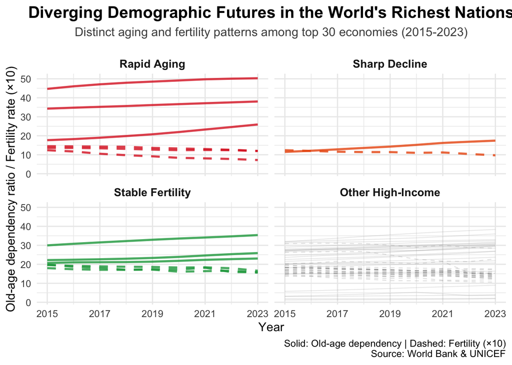

```r
plot_df <- plot_df %>%
  mutate(
    pattern_type = case_when(
      country %in% c("Japan", "South Korea", "Italy", "Spain", "Greece") ~ "Rapid Aging",
      country %in% c("United States", "France", "New Zealand", "Iceland") ~ "Stable Fertility",
      country %in% c("Singapore", "Macao", "Hong Kong") ~ "Sharp Decline",
      TRUE ~ "Other High-Income"
    ),
    pattern_type = factor(pattern_type,
                         levels = c("Rapid Aging", "Sharp Decline",
                                   "Stable Fertility", "Other High-Income"))
  )

p2 <- ggplot(plot_df, aes(x = year, group = country)) +
  geom_line(data = filter(plot_df, pattern_type == "Other High-Income"),
            aes(y = old_age_dependency),
            alpha = 0.2, color = "gray60", linewidth = 0.4) +
  geom_line(data = filter(plot_df, pattern_type == "Other High-Income"),
            aes(y = fertility_rate * 10),
            alpha = 0.2, color = "gray40", linewidth = 0.4, linetype = "dashed") +
  geom_line(data = filter(plot_df, pattern_type != "Other High-Income"),
            aes(y = old_age_dependency, color = pattern_type),
            linewidth = 1, alpha = 0.8) +
  geom_line(data = filter(plot_df, pattern_type != "Other High-Income"),
            aes(y = fertility_rate * 10, color = pattern_type),
            linewidth = 1, alpha = 0.8, linetype = "dashed") +
  facet_wrap(~ pattern_type, ncol = 2) +
  scale_color_manual(
    values = c("Rapid Aging" = "#dc2626",
               "Sharp Decline" = "#ea580c",
               "Stable Fertility" = "#16a34a",
               "Other High-Income" = "gray50"),
    name = "Pattern Group"
  ) +
  scale_x_continuous(breaks = seq(2015, 2023, 2)) +
  labs(
    title = "Diverging Demographic Futures in the World's Richest Nations",
    subtitle = "Distinct aging and fertility patterns among top 30 economies (2015-2023)",
    x = "Year",
    y = "Old-age dependency ratio / Fertility rate (×10)",
    caption = "Solid: Old-age dependency | Dashed: Fertility (×10)\nSource: World Bank & UNICEF"
  ) +
  theme_minimal(base_size = 12) +
  theme(
    plot.title = element_text(face = "bold", size = 16, hjust = 0.5),
    plot.subtitle = element_text(size = 12, color = "gray30", hjust = 0.5, margin = margin(b = 15)),
    strip.text = element_text(face = "bold", size = 11),
    legend.position = "none"
  )

print(p2)
```

## Attempt 3: Simple Multi-Line Chart (Nikita)

**Why we tried this:** Wanted a single comprehensive view where you could see all trends at once and compare countries directly.

**Decision:** Aggregate countries by income groups to show clearer macro-patterns. This became our first visualization in the final report showing High Income vs Low Income fertility trends.

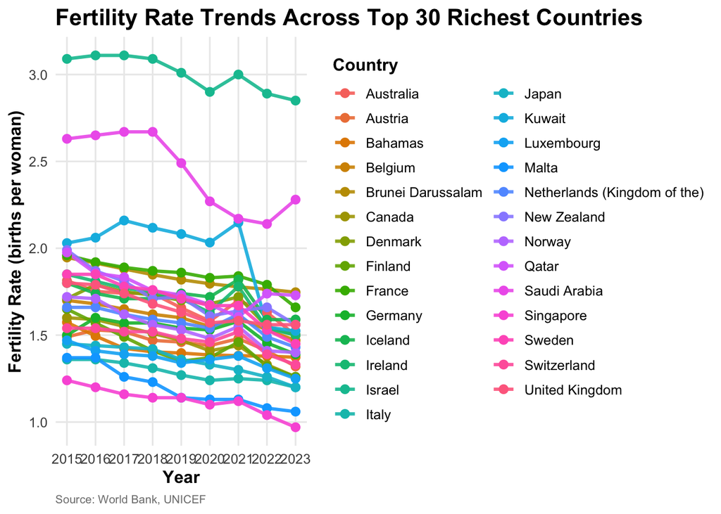

```r
line_data <- final_dataset %>%
  filter(country %in% top_30_richest,
         !is.na(fertility_rate))

ggplot(line_data, aes(x = year, y = fertility_rate, color = country, group = country)) +
  geom_line(size = 1.1, alpha = 0.9) +
  geom_point(size = 2.5) +
  scale_x_continuous(breaks = seq(2015, 2023, 1)) +
  labs(
    title = "Fertility Rate Trends Across Top 30 Richest Countries",
    x = "Year",
    y = "Fertility Rate (births per woman)",
    color = "Country",
    caption = "Source: World Bank, UNICEF"
  ) +
  theme_minimal(base_size = 12) +
  theme(
    plot.title = element_text(face = "bold", size = 16, margin = margin(b = 5)),
    plot.subtitle = element_text(size = 11, color = "gray30", margin = margin(b = 15)),
    plot.caption = element_text(hjust = 0, size = 8, color = "gray50"),
    legend.position = "right",
    legend.title = element_text(face = "bold"),
    panel.grid.minor = element_blank(),
    axis.title = element_text(face = "bold")
  )
```

## Attempt 4: Bubble Chart Experiment (Nikita)

**Why we tried this:** Wanted to show three variables at once in an engaging visual format popular in data journalism.

**Why it didn’t work:** Hard to see temporal trends since it was just one snapshot. Bubble sizes were distracting and didn’t add much insight. Static image didn’t let users explore the data.

**Decision:** Moved to scatterplots with trajectory lines showing change over time, which better illustrated the relationship between empowerment and fertility decline.

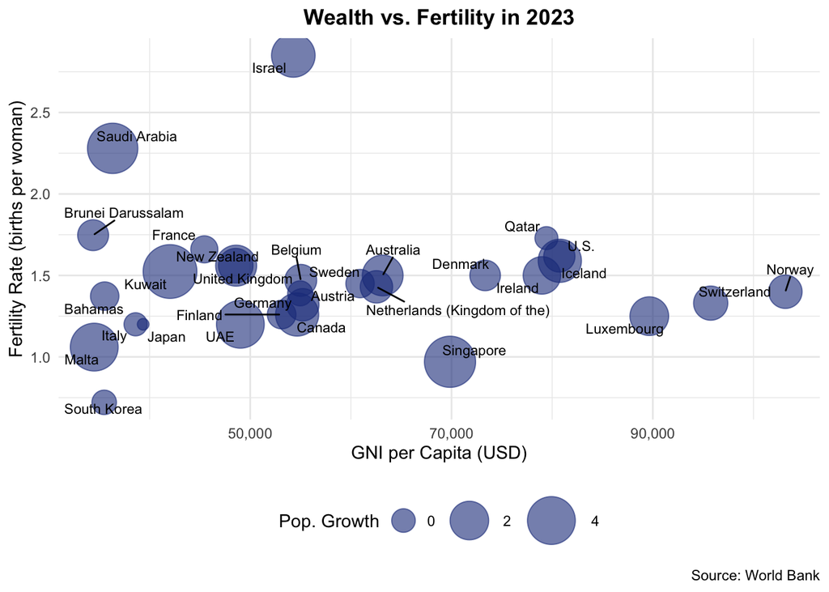

```r
bubble_data <- final_dataset_30 %>%
  filter(year == 2023, !is.na(gni_per_capita), !is.na(fertility_rate))

ggplot(bubble_data, aes(x = gni_per_capita, y = fertility_rate)) +
  geom_point(aes(size = population_growth), alpha = 0.6, color = "#1e3a8a") +
  geom_text_repel(aes(label = country), size = 3, max.overlaps = 15) +
  scale_x_continuous(labels = comma) +
  scale_size_continuous(range = c(3, 15)) +
  labs(
    title = "Wealth vs. Fertility in 2023",
    x = "GNI per Capita (USD)",
    y = "Fertility Rate (births per woman)",
    size = "Pop. Growth",
    caption = "Source: World Bank"
  ) +
  theme_minimal() +
  theme(
    plot.title = element_text(face = "bold", hjust = 0.5),
    legend.position = "bottom"
  )
```

# Summary of Exploration Process

## What Worked:

- **Income-based grouping** (World Bank classifications) provided clear, objective narrative structure
- **Interactive plotly charts** allowed deeper exploration without overwhelming static views
- **Scatterplots with trajectory lines** effectively showed relationships between empowerment and fertility over time
- **Heatmaps** made policy comparisons across 30 countries visually intuitive and scannable
- **Faceting by empowerment dimension** (education, labor, finance, unpaid work) revealed nuanced patterns

## What Didn’t Work:

- **Country-by-country facets** were too detailed; cognitive overload with 30 panels
- **Pattern-based categorization** felt arbitrary and couldn’t be defended rigorously
- **Multi-line charts with 30+ countries** became spaghetti plots - completely unreadable
- **Dual y-axes** made comparisons confusing rather than clarifying
- **Bubble charts** looked nice but didn’t communicate temporal change effectively
- **Static plots for complex data** - needed interactivity for user engagement